This is a submission for Reproduceable Reasearch, peer assessment 1.

First load the data into a data frame named “activity” and load lattice and plyr.

```r
setwd("~/Documents/CourseraDS")
activity = read.csv("activity.csv")
library(package = "lattice")
library(plyr)
```

# Transform the data

Change date column to be in date format

```r
activity$date <- as.Date(activity$date)
```

Ignore missing values

```r
activity_c <- activity[complete.cases(activity),]
```

# What is mean total number of steps taken per day?

Create a data set grouped by day:

```r
activity_byDay <- aggregate(activity_c$steps, by=list(date = activity_c$date), FUN = sum)
```

Histogram of steps by day:

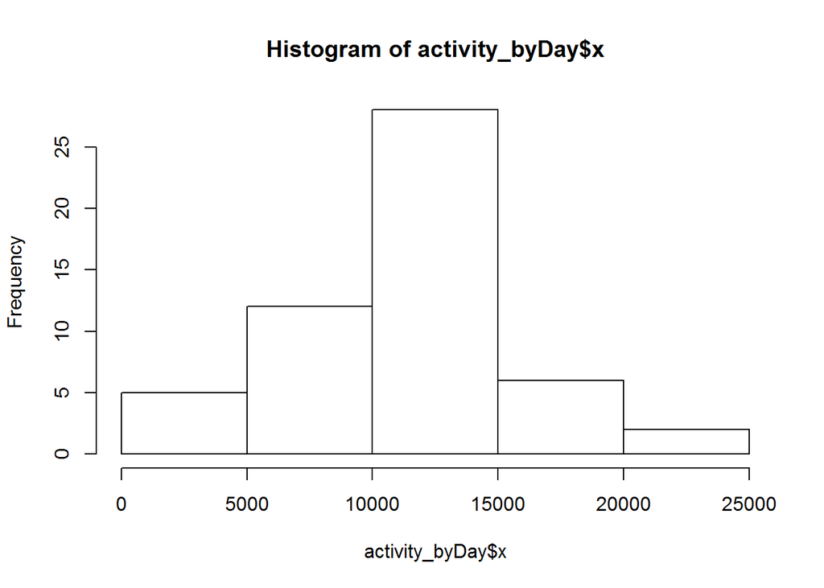

```r
hist(activity_byDay$x)
```

Mean:

```r
mean(activity_byDay$x)
```

```
## [1] 10766.19
```

Median

```r
median(activity_byDay$x)
```

```
## [1] 10765
```

# What is the average daily activity pattern?

Create dataframe grouped by interval

```r
activity_byInt <- aggregate(activity_c$steps, by=list(Int = activity_c$interval), FUN = mean)
```

Plot average activity by interval

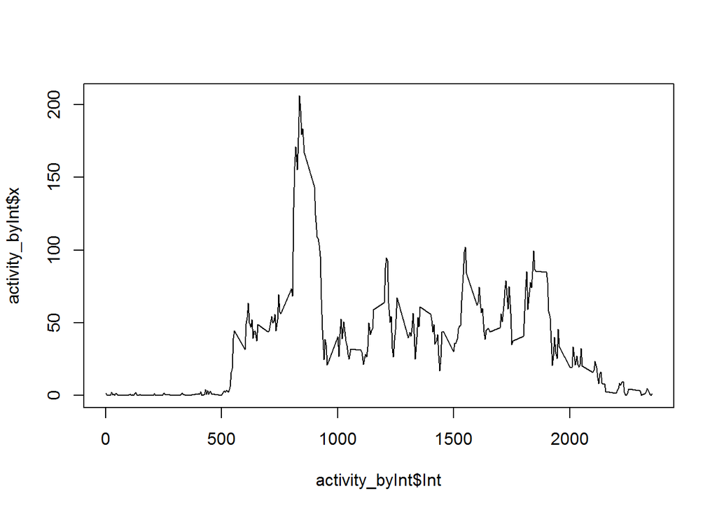

```r
plot(activity_byInt$Int,activity_byInt$x, type = "l")
```

The interval with the max average step count

```r
max_step <- max(activity_byInt$x)
activity_byInt[activity_byInt$x == max_step,]
```

```
##     Int        x
## 104 835 206.1698
```

# Imputing missing values

Number of missing values.

```r
sum(is.na(activity))
```

```
## [1] 2304
```

I will replace missing values with the mean of steps in the cleaned dataframe.

```r
meanStep <- mean(activity_c$steps)
activity_impute <- activity
activity_impute[is.na(activity_impute)] <- meanStep
```

Group the cleaned data by day.

```r
activity_imp_byDay <- aggregate(activity_impute$steps, by=list(date = activity_impute$date), FUN = sum)
```

Make a histogram. Multiply by 1 to force coercian from factor.

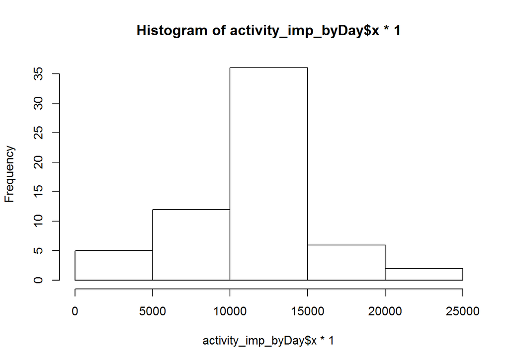

```r
hist(activity_imp_byDay$x * 1)
```

Mean:

```r
mean(activity_imp_byDay$x)
```

```
## [1] 10766.19
```

Median

```r
median(activity_imp_byDay$x)
```

```
## [1] 10766.19
```

The imputation of missing values has the effect of making the median very close to the mean. The histogram also has a higher frequency in the center bucket.

# Differences between weekdays and weekends

Modify data set to contain weekday data

```r
activity_impute[,'Weekday'] = weekdays(activity_impute$date)
activity_impute[,'IsWeekend'] <- ifelse((activity_impute$Weekday == "Saturday" | activity_impute$Weekday == "Sunday"), "Weekend","Weekday" )
```

Create dataframe grouped by interval

```r
activity_imp_byInt <- aggregate(activity_impute$steps, by=list(Int = activity_impute$interval,IsWeekend = activity_impute$IsWeekend), FUN = mean)
```

Graph the results.

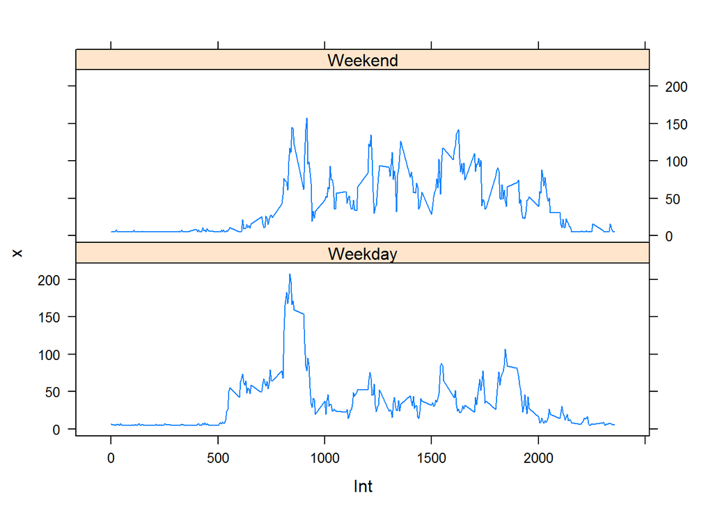

```r
xyplot(x ~ Int | IsWeekend, data = activity_imp_byInt, type = "l",layout = (c(1,2)))
```